# Vignette_2: Data Visualization with TCGA KIRP LATE vs EARLY stage patients

# StellarPath

Welcome to the second vignette of our software StellarPath. This vignette focuses on visualizing the data produced by StellarPath. We hope to provide some ideas on how to investigate and elaborate our method’s results.

## Note

Before checking this vignette, we suggest to go through Vignette_1. In this vignette, we will not describe each operation and the workflow. For some plots, we will limit the data to plot to create figures that fit in the html vignette. In a real application, we suggest to not subsample the data but to produce the plot in an independent pdf.

## Case study

For this vignette, StellarPath is applied on a simple experimental study:

- We have: Kidney renal papillary cell carcinoma patient’s samples divded by cancer stage: LATE vs EARLY
- We have: bulk RNA sequencing, small RNA sequencing and somatic mutation data for all the samples in study
- We want: deregulated pathways and molecules between LATE and EARLY cancer stage
- We want: information to further prioritize and investigate pathways and molecules
- We want: find a predictive pathway for EARLY cancer stage patients and check up the patient’s similarities
- We want: find molecular markers for EARLY cancer stage patients
- We want: check up the pathway activity of all the patients in the significant pathway specific PSNs to detect subclasses

# Enviroment set up

Let us clean the R enviroment, set the working directory, load the software package, set the random seed generator for reproducing always the same results and define the number of cores available in the computer to run the operations. Be careful: set up the number of cores based on your resources, if you are not secure how to, then just set equal to 2

```r
#Clean workspace and memory ----
rm(list=ls())
gc()
```

```
#>          used (Mb) gc trigger (Mb) max used (Mb)
#> Ncells 514733 27.5    1137874 60.8   665582 35.6
#> Vcells 952367  7.3    8388608 64.0  1819332 13.9
```

```r
#Set working directory ----
gps0=getwd()
gps0=paste(gps0,"/%s",sep="")
rootDir=gps0
setwd(gsub("%s","",rootDir))
set.seed(5)

#Load libraries ----
library("StellarPath")
library("qs")
library("data.table")
```

```r
library("ggplot2")
library("pheatmap")
library("ggrepel")

#Set variables ----
#Input
#Set the number of cores available in the system
n_cores=15
#output
#Set the output file where all the data and results will be stored in the end
out_res_path="classif_KIRP.qs"
```

# Data set up

StellarPath is a binary classifier and works with one or multiple omics from high-throughput sequencing describing the two patient classes in comparison. For this vignette, we load the TCGA data that StellarPath includes in the package and extract the information about KIRP patients. Then, we run the main workflow on KIRP data.

```r
#Load and set up the example data ----
data("tcga_p2_l")
tcga_l=tcga_p2_l

#Set name of the project, the specie id of the samples, the name of the classes to compare (case vs control)
name_dataset="KIRP"
tax_id=9606
groups=c("LATE","EARLY")

#Start monitor RAM memory
log_path=start_monitor_ram(name_dataset)
```

```
#> Starting to monitor the RAM usage
```

```r
#Start monitor running time
startTime=Sys.time()

data_l=prepare_data(info = tcga_l[[name_dataset]]$info[,c("patientID","pathologic_stage_binary")],
                    groups_name = c("LATE","EARLY"),
                    mRNA = tcga_l[[name_dataset]]$omics$RNASeq2Gene,
                    miRNA = tcga_l[[name_dataset]]$omics$miRNASeqGene,
                    mutations = tcga_l[[name_dataset]]$omics$Mutation,
                    tax_id = tax_id,
                    n_cores = n_cores);tmp=gc();
```

```
#> Checking input omics/raw count matrices
#> >the mRNAseq (mRNA per samples) has been provided
#> >the miRNAseq (miRNA per samples) has been provided
#> >the mutations (genes per samples) have been provided
#> Checking input info
#> >dataframe format
#> >two columns
#> >does NOT contain NA values
#> >groups in comparison are two
#> >second column of info contains only labels which belong to the user defined group's names
#> Checking same sample's IDs between info first column and omics column names
#> >same order of existing samples between info dataframe and omics data
#> Checking format of input omics
#> >omics are in the same format
#> >omics are matrices
#> Ordering samples based on groups
#> >The comparison and classification is with:
#> >>first group : LATE of samples: 46
#> >>second group : EARLY of samples: 104
#> Simplifying sample's names in info and omics data
#> >>from: TCGA-A4-8310 to: LATE.1
#> >>original sample's IDs remain as rownames of the info dataframe
#> Loading human databases
#> Processing and Normalizing omics
#> >preparing mRNA
#> >>number of genes falling into pathways: 15512
#> >>number of lncRNAs having target sets of genes: 82
#> >preparing miRNA
#> >>number of miRNAs having target sets of genes: 1347
#> >preparing somatic mutations
#> >>number of mutated genes falling into pathways: 7668
#> >>network-based propagation
#> >>>harmonizing count matrix with a biological network
#> >>>the following number of sample's rownames are missing as nodes: 199
#> >>>parallel for Linux and Mac
#> >>>keeping samples's molecules not represented as nodes
#> >>end propagation
#> Preparing partitions of data for cross validation setting
```

```r
#Find the pathways that in the training data produce a significant PSN
data_l=analyse_training(data_l)
```

```
#> Feature selection of training data belonging to: 1 run of cross validation
#> >training samples:
#> >>first group: LATE of training samples: 33
#> >>second group: EARLY of training samples: 75
#> >finding significant group specific genes based on gene expression and update $TRAINING$omics$gex
#> >>finding enriched pathways and keep the ones with best PSNs
#> >finding significant group specific mutated genes based on propagated mutations and update $TRAINING$omics$mutations
#> >>finding enriched pathways and keep the ones with best PSNs
#> >finding significant group specific miRNAs based on miRNA expression and update $TRAINING$omics$miRNA
#> >>finding enriched miRNA's gene targets and keep the ones with best PSNs
#> >finding significant group specific lncRNAs based on lncRNA expression and update $TRAINING$omics$lncRNA
#> >finding top enriched gene targets from significant lncRNAs
#> >>finding enriched lncRNA's gene targets and keep the ones with best PSNs
#> >>finding enriched lncRNA's miRNA targets and keep the ones with best PSNs
#> >>finding enriched miRNA's lncRNA targets and keep the ones with best PSNs
#> >adding significant pathways/targets/PSNs into $TRAINING$pathway_analysis
#> Feature selection of training data belonging to: 2 run of cross validation
#> >training samples:
#> >>first group: LATE of training samples: 33
#> >>second group: EARLY of training samples: 75
#> >finding significant group specific genes based on gene expression and update $TRAINING$omics$gex
#> >>finding enriched pathways and keep the ones with best PSNs
#> >finding significant group specific mutated genes based on propagated mutations and update $TRAINING$omics$mutations
#> >>finding enriched pathways and keep the ones with best PSNs
#> >finding significant group specific miRNAs based on miRNA expression and update $TRAINING$omics$miRNA
#> >>finding enriched miRNA's gene targets and keep the ones with best PSNs
#> >finding significant group specific lncRNAs based on lncRNA expression and update $TRAINING$omics$lncRNA
#> >finding top enriched gene targets from significant lncRNAs
#> >>finding enriched lncRNA's gene targets and keep the ones with best PSNs
#> >>finding enriched lncRNA's miRNA targets and keep the ones with best PSNs
#> >>finding enriched miRNA's lncRNA targets and keep the ones with best PSNs
#> >adding significant pathways/targets/PSNs into $TRAINING$pathway_analysis
```

```r
#Classify the testing patients based on the features/pathways learnt from the training
data_l=classify_testing(data_l)
```

```
#> Classification Peformance of the run: 1 is: 1
#> Updating $TESTING$classification in TESTING data list
#> Classification Peformance of the run: 2 is: 1
#> Updating $TESTING$classification in TESTING data list
```

```r
#End monitor resources
runningTime=convert_min2h(difftime(Sys.time(), startTime, units='mins')[[1]])
max_ram=get_max_ram_used(log_path)
```

```
#> Determining the max RAM used
```

```r
resources_l=list(runningTime=runningTime, max_ram=max_ram)
#Update the performance list
data_l$performances$performances$name_dataset=name_dataset
data_l[["performances"]]=c(data_l[["performances"]],resources_l)

#Running time
cat("Classification performed in", runningTime, "hours and with", max_ram, "GB of RAM")
```

```
#> Classification performed in 0.16 hours and with 26 GB of RAM
```

```r
#Retrieve best pathways/target sets and their PSNs used in the classification
data_l[["enrichment"]]=enrichment_analysis(data_l)
```

```
#> Enrichment with predictions of the run: 1 of cross validation with best performances
#> Feature selection of training data belonging to: 1 run of cross validation
#> >training samples:
#> >>first group: LATE of training samples: 46
#> >>second group: EARLY of training samples: 104
#> >finding significant group specific genes based on gene expression and update $TRAINING$omics$gex
#> >>finding enriched pathways and keep the ones with best PSNs
#> >finding significant group specific mutated genes based on propagated mutations and update $TRAINING$omics$mutations
#> >>finding enriched pathways and keep the ones with best PSNs
#> >finding significant group specific miRNAs based on miRNA expression and update $TRAINING$omics$miRNA
#> >>finding enriched miRNA's gene targets and keep the ones with best PSNs
#> >finding significant group specific lncRNAs based on lncRNA expression and update $TRAINING$omics$lncRNA
#> >finding top enriched gene targets from significant lncRNAs
#> >>finding enriched lncRNA's gene targets and keep the ones with best PSNs
#> >>finding enriched lncRNA's miRNA targets and keep the ones with best PSNs
#> >>finding enriched miRNA's lncRNA targets and keep the ones with best PSNs
#> >adding significant pathways/targets/PSNs into $TRAINING$pathway_analysis
```

```r
#Save results
qsave(data_l,file = out_res_path, nthreads = n_cores)
```

# Data Extraction

Let us extract the data and results produced by StellarPath

```r
#Extract stable differential expression analysis about molecules (e.g. genes)
sdr=data_l$enrichment$omics$gex$SDR

#Extract and format the classification performance of the GCN with each significant pathway specific PSN
perfsXpathway_dfs=rbindlist(data_l$performances$perfsXpathway_dfs)

#Extract and format the significant pathway specific PSN
transc=data_l$enrichment$pathway_analysis$transcriptomics$top_pathways_df
muts=data_l$enrichment$pathway_analysis$mutations$top_pathways_df
muts_extra=data.frame(code_db=rep(NA,nrow(muts)),
                      name_db=rep(NA,nrow(muts)),
                      pathways_targets=rep(NA,nrow(muts)),
                      code_db_targets=rep(NA,nrow(muts)))
muts=cbind(muts,muts_extra)
paths=rbind(transc,muts)

#Extract how much each patient is central in the pathway specific PSNs of the transcriptomics data
centralities=sapply(data_l$enrichment$pathway_analysis$transcriptomics$top_pathways_l,function(x){
  as.numeric(x$centrality)
})
rownames(centralities)=names(data_l$enrichment$pathway_analysis$transcriptomics$top_pathways_l[[1]]$centrality)
centralities=t(centralities)
```

# Plot

We can now start to produce the plots to visualize the data and results about the classification and the patients.

## GCN performance per PSN

We want to understand how much the GCN performed with each pathway specific PSN.

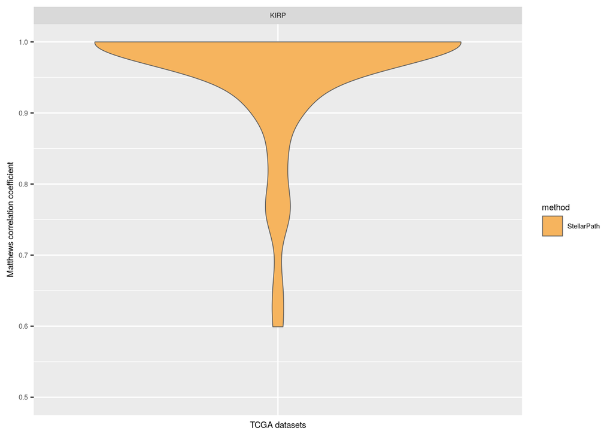

```r
perfsXpathway_dfs$dataset=name_dataset
perfsXpathway_dfs$method="StellarPath"
ggplot(perfsXpathway_dfs, aes(x=dataset, y=test_MCC, fill=method)) +
  geom_violin(color="grey35",lwd=0.3,scale="width") +
  scale_fill_manual(values = c('#f6b45e','#365b9f')) +
  theme(text = element_text(size=7)) +
  labs(y = "Matthews correlation coefficient", x="TCGA datasets") +
  facet_grid(~ dataset, scales = "free") +
  theme(axis.ticks.x=element_blank(), axis.text.x=element_blank()) +
  ylim(0.5, 1)
```

We can say that the GCN managed to predict very good the testing patients in most of the significant pathway specific PSNs involved in the different runs of cross-validation. This means that we can consider the results coming out this classification because pathways and molecules will be both deregulated and predictive.

## Pathway Ranking

We plot the statistics of the significant pathway specific PSNs. This plot allows to summarize the most important statistics about PSNs and let us prioritize which pathways to study further. Precisely, we plot:

- Separability Power: (how much the classes in study are separated in the PSN and how much one class is cohesive while the second one is sparse)
- Group: the patient’s class that is cohesive in the PSN and also the class whose molecular markers are deregulated in the pathway
- Regulation Type: if the pathway is activated or inhibited by the deregulated molecules of the cohesive class
- Group’s cohesion: indicates the smallest similarity between the patients of the cohesive class

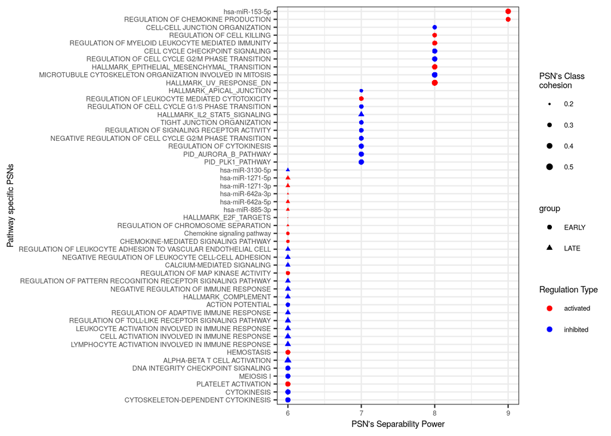

```r
x=paths[1:50,]
x=x[order(x$power,decreasing = FALSE),]
x$pathways=factor(x$pathways,ordered = TRUE,levels = x$pathways)
ggplot(x, aes(y=pathways, x=power, color=regulation, shape=group, size=min_intra_STRONG)) +
  geom_point() + theme_bw() +
  scale_color_manual(breaks = c("activated", "inhibited"), values=c("red", "blue")) +
  labs(x="PSN's Separability Power", y="Pathway specific PSNs",
       color="Regulation Type", size="PSN's Class\ncohesion") +
  theme(text = element_text(size=7)) +
  scale_size(range = c(0, 2))
```

## PSN graph plot

From the previous plot, we see that EARLY cancer stage patients have activated the pathway “CELL KILLING” probably to limit the proliferation of the tumor. We want to see precisely the EARLY patients that have activated the pathway, so we plot the network.

```r
#Extract informaiton about a pathway specific PSN of interest
path_name="REGULATION OF CELL KILLING"
knitr::kable(data_l$enrichment$pathway_analysis$transcriptomics$top_pathways_l[[path_name]]$stats)
```

| regulation | group | power | min_intra_STRONG | max_intra_WEAK | max_inter_similarities |
| --- | --- | --- | --- | --- | --- |
| activated | EARLY | 8 | 0.3822923 | 0.236086 | 0.3788229 |

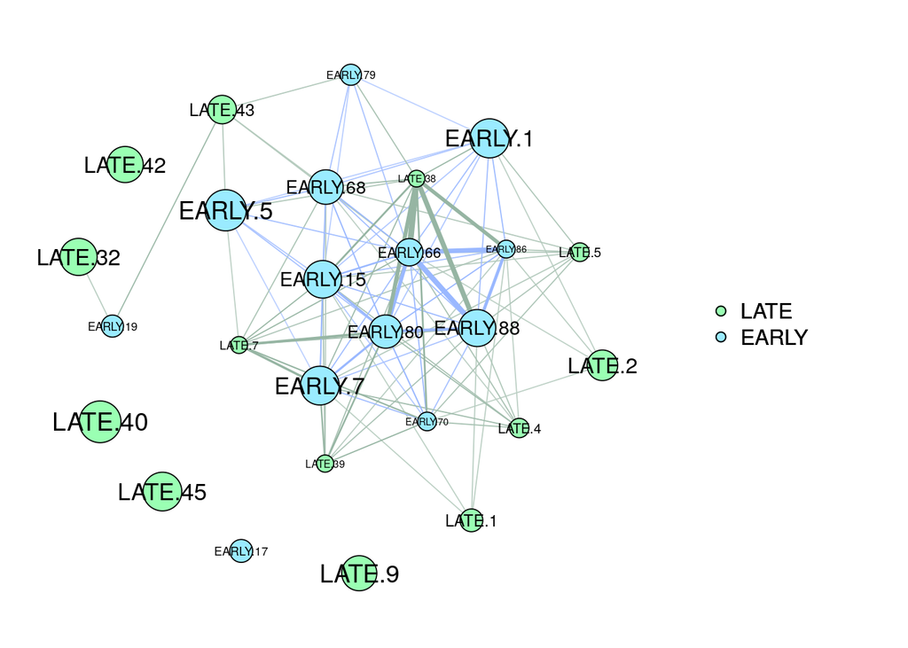

```r
PSN=data_l$enrichment$pathway_analysis$transcriptomics$top_pathways_l[[path_name]]$PSN
info=data_l$enrichment$info
pl_l=plot_PSN(info,PSN,k_clusters = 13,edge_threshold = 0.3,GLratio = 3)
```

It seems that the following EARLY patients are quite important for their class:

```r
pl_l$names_in_k_l$EARLY.79
```

[1] “EARLY.10” “EARLY.24” “EARLY.36” “EARLY.40” “EARLY.41” “EARLY.51” [7] “EARLY.55” “EARLY.63” “EARLY.79” “EARLY.90” “EARLY.92”

If we want to get the original names of the patient’s samples which can be outliers for the CELL KILLING pathways:

```r
plyr::mapvalues(pl_l$names_in_k_l$EARLY.79, from=info$IDs, to=rownames(info), warn_missing = FALSE)
```

[1] “TCGA-A4-8517” “TCGA-B1-A656” “TCGA-BQ-5881” “TCGA-BQ-5892” “TCGA-BQ-7045” [6] “TCGA-DW-5561” “TCGA-DW-7839” “TCGA-DZ-6135” “TCGA-HE-A5NF” “TCGA-KV-A6GE” [11] “TCGA-MH-A55Z”

## Molecular Markers

We plot the statistics of the significant molecules that StellarPath found deregulated in expression and stability in the CELL KILLING pathway. This plot allows to summarize the most important statistics about the deregulated molecules and let us prioritize which molecules to study further. Precisely, we plot:

- logFoldChange: how much the molecule is deregulated in term of expression values in the comparison LATE vs EARLY
- Stability: how much the molecule is deregulated in term of variance of the expression values in the comparison LATE vs EARLY (more the value is lower and more the molecule has a more stable expression in EARLY patients)
- Activity_EARLY: Relative expression value of the molecule in the EARLY class

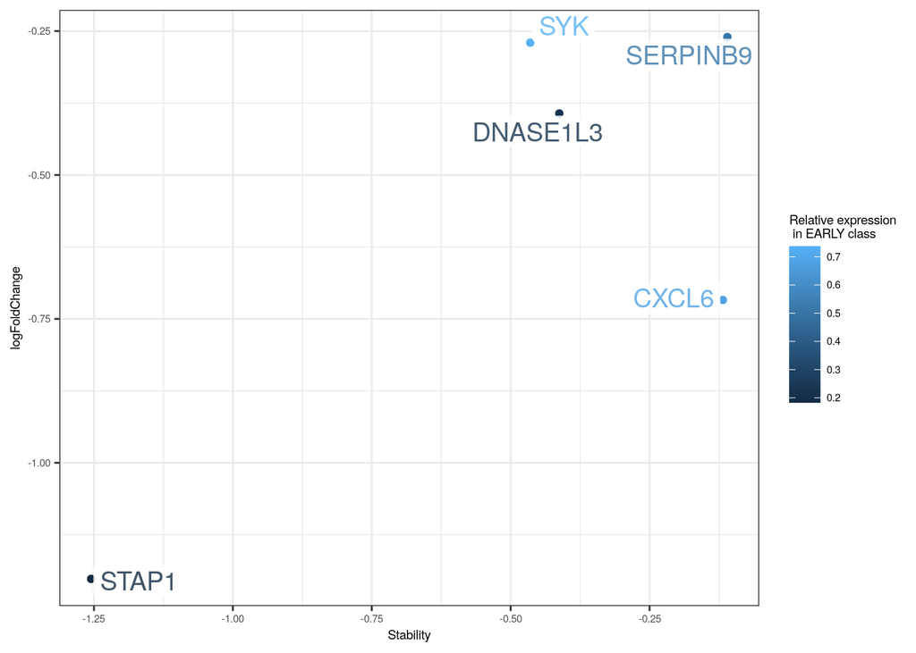

```r
#Extract the set of molecules that enriched the pathway of interest
mls=data_l$enrichment$pathway_analysis$transcriptomics$top_pathways_l[[path_name]]$set
#Extract the stats about the molecules
sdr_mls=sdr[mls,]
sdr_mls$names=rownames(sdr_mls)

ggplot(sdr_mls, aes(y=logFoldChange, x=Stability, color=Activity_EARLY)) +
  geom_point() + theme_bw() +
  labs(x="Stability", y="logFoldChange",
       color="Relative expression\n in EARLY class") +
  theme(text = element_text(size=7)) +
  geom_label_repel(aes(label = names),
                   box.padding   = 0,
                   point.padding = 0.1,
                   size = 5, alpha=0.8, max.overlaps=5, label.size = NA, fill = "white",
                   segment.color = 'grey50')
```

The gene STAP1 seems to be the most important deregulated markers in the CELL KILLING pathway for EARLY cancer stage patients. It is actually involved with their pathology: https://www.proteinatlas.org/ENSG00000035720-STAP1/pathology

## Centralities in pathway specific PSNs

In the end, we also want to plot how much each patient is central in each pathway specific PSN. This plot allows to understand if there are subclasses inside the classes in study or there are outliers. For example, we have suclasses of LATE cancer stage patients if a large subset of patients is central in only some pathways and not central in others. We don’t have subclasses if LATE cancer stage patients are all central in all the significant pathways. We have outlier patients if a small subset of LATE patients is not central in only some pathways.

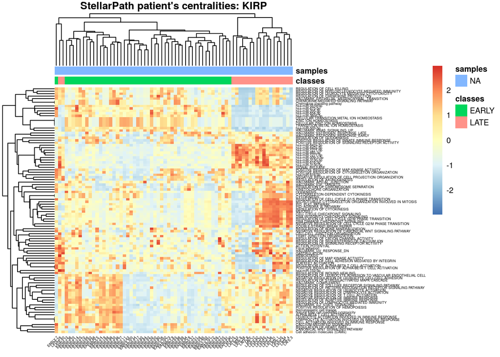

```r
#We set up the annotation dataframe for the columns/samples in order to see their class in the plot
classes=sub("\\..*", "",colnames(centralities))
anno=data.frame(ids=colnames(centralities),classes=classes,samples="NA")
rownames(anno)=anno$ids
anno=anno[,-1]

#We plot a subset of the centrality matrix to simplify the plot for the vignette
pheatmap(
  centralities[1:100,sample(seq(1,ncol(centralities)))[1:70]], scale = "row",
  main=paste("StellarPath patient's centralities:",name_dataset),
  fontsize=8,
  fontsize_row=3.5,
  fontsize_col=3.5,
  angle_col=45,
  annotation_col = anno
)
```